# ¿Qué tan cerca estoy de la ubicación de mis compañeras y compañeros?

Joyce Cruz,Natalia Perez,Nisa Gonzalez,David Martinez

11/11/2020

### I. Creando nuestros datos

```r
JoyceCruz<-c(-109.776389,23.369167)
NataliaPerez<-c(-99.6468,19.2879)
NisaGonzalez<-c(-90.5237,19.8454)
DavidMartinez<-c( -99.09889,21.59972)
viajes<-rbind(JoyceCruz,NataliaPerez,NisaGonzalez,DavidMartinez)
viajes
```

```
##                     [,1]     [,2]
## JoyceCruz     -109.77639 23.36917
## NataliaPerez   -99.64680 19.28790
## NisaGonzalez   -90.52370 19.84540
## DavidMartinez  -99.09889 21.59972
```

### II. Cambiando el nombre de nuestras columnas

Una vez que hemos creado nuestra matriz de datos, cambiaremos el nombre de nuestras columnas con la función `colnames`:

```r
colnames(viajes)<-c("Longitud","Latitud")
viajes
```

```
##                 Longitud  Latitud
## JoyceCruz     -109.77639 23.36917
## NataliaPerez   -99.64680 19.28790
## NisaGonzalez   -90.52370 19.84540
## DavidMartinez  -99.09889 21.59972
```

### III. Transformando nuestra matriz en un data.frame

Recuerda que para hacer gráficas con `ggplot` y mapas con `qmplot` necesitamos un data frame. Vamos a transformar nuestra matriz en un data.frame de la siguiente forma:

```r
viajes<-data.frame(viajes)
viajes
```

```
##                 Longitud  Latitud
## JoyceCruz     -109.77639 23.36917
## NataliaPerez   -99.64680 19.28790
## NisaGonzalez   -90.52370 19.84540
## DavidMartinez  -99.09889 21.59972
```

### IV. Creando una gráfica de dispersión con nombres y puntos

Podemos crear una grafica de dispersión y usar los nombres como etiqueta si utilizamos la función `ggplot` junto con `geom_text`; además, podemos agregar puntos a nuestra gráfica con la función `geom_point`. Finalmente, si queremos que nuestra gráfica sea interactiva, utilizamos la función `ggplotly`:

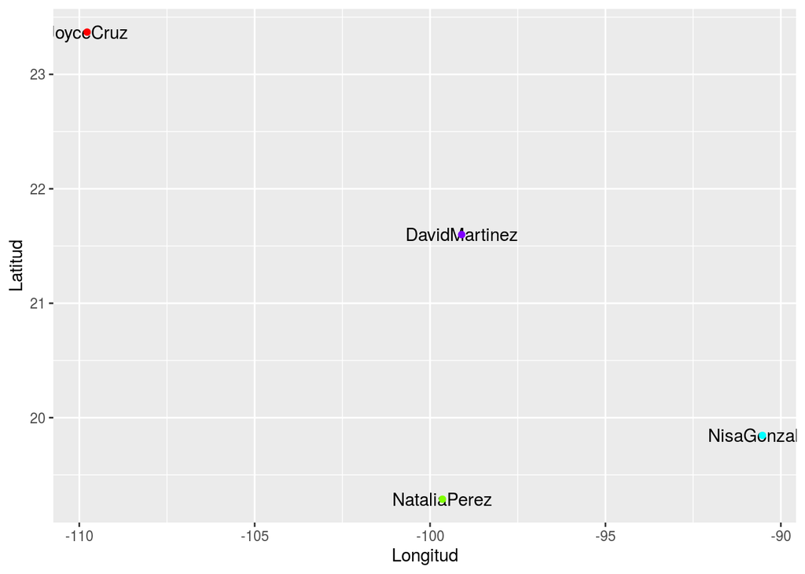

```r
dispersion<-ggplot(viajes)+geom_text(aes(Longitud,Latitud),label= rownames(viajes))+geom_point(aes(Longitud,Latitud),color=rainbow(4))
dispersion
```

### V. Creando un mapa

Para crear un mapa, utilizaremos la funcion `qmplot`:

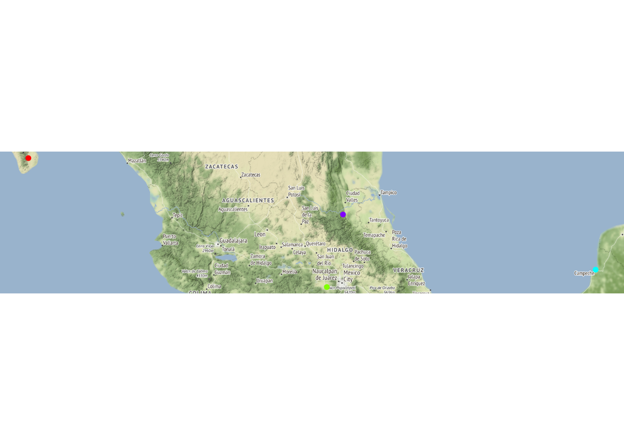

```r
qmplot(Longitud, Latitud, data=viajes, color=I(rainbow(4)))
```

### VI. Mapa de puntos y denssidad

Podemos agregar el parámetro `geom = c("point","density2d")` para hacer un mapa de puntos y densidad:

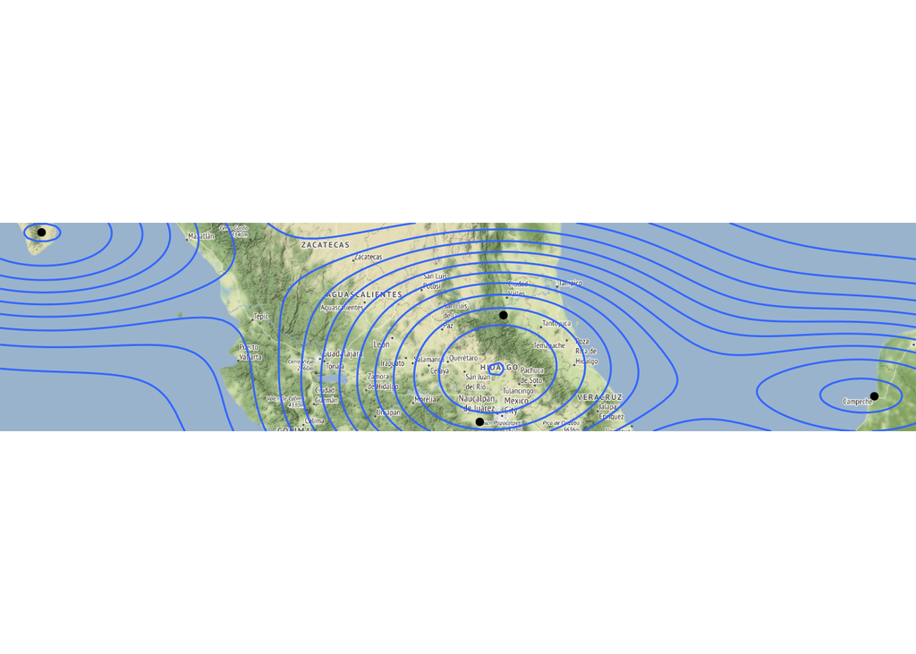

```r
qmplot(Longitud, Latitud, data=viajes, geom=c("point","density2d"))
```

### 1.- ¿Cómo están distribuidas sus ubicaciones?

Muy dispersas, solamente dos puntos comparten el mismo conjunto.

### 2.- Si tuvieras que pensar en una función que pasara por todas sus ubicaciones, ¿qué tipo de función sería?

Se asemeja a una funcion racional.

### 3.- ¿Consideras que graficar la ubicación de una persona en un mapa tiene un valor económico? ¿Por qué?

Si. Por ejemplo al momento de segmentar publicos para una estrategia publicitaria. Ademas podemos conocer las zonas de mayor flujo economico.

### 4.- ¿Hasta ahora qué han aprendido en el curso?

Graficar, manejar nuevos programas, conocer la importancia de la tecnologia relacionada a la economia, utilizar lenguaje basico de programacion.

Esta obra fue generada mediante R en November 20, 2020 y forma parte de las actividades realizadas en las materias de [Matemáticas I y Taller III](https://mateytaller.github.io/), [Facultad de Economía, UNAM](http://economia.unam.mx/).  
Esta obra está bajo una [licencia de Creative Commons Reconocimiento-NoComercial-CompartirIgual 4.0 Internacional.](http://creativecommons.org/licenses/by-nc-sa/4.0/) [Creative Commons (CC)](http://creativecommons.org/licenses/by-nc-sa/4.0/).